# Stat388Project

## XGBoost

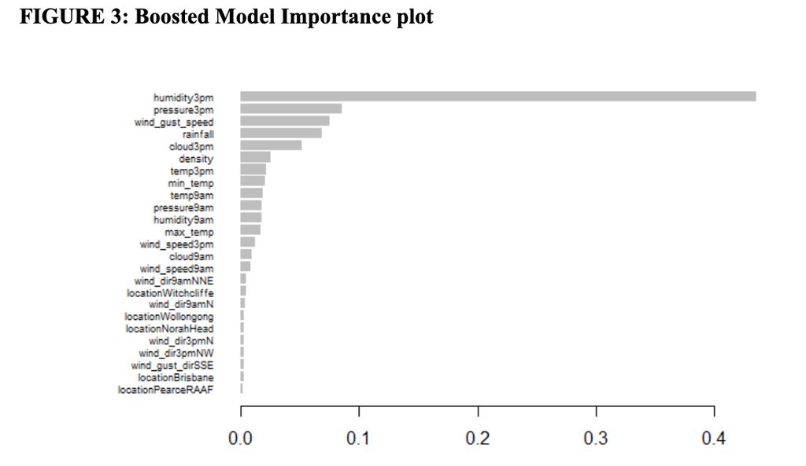

```r
knitr::include_graphics("Screen Shot 2021-12-14 at 10.59.19 PM.png")
```

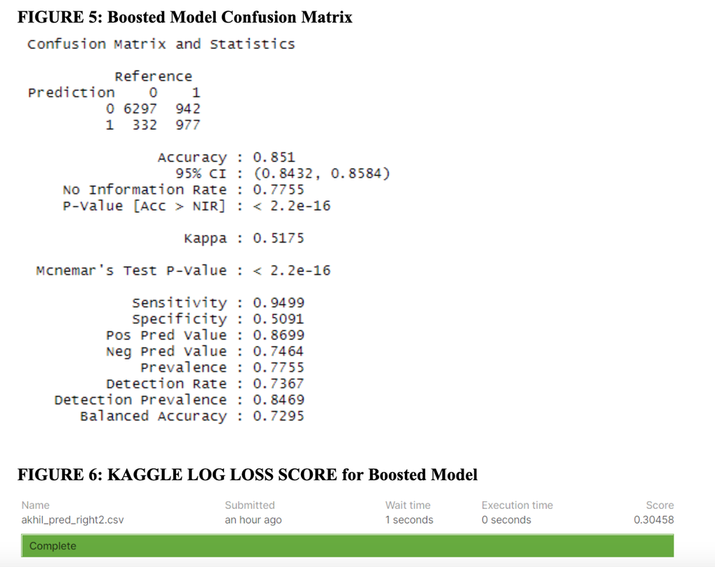

```r
knitr::include_graphics("Screen Shot 2021-12-14 at 11.05.08 PM.png")
```

## Bagging

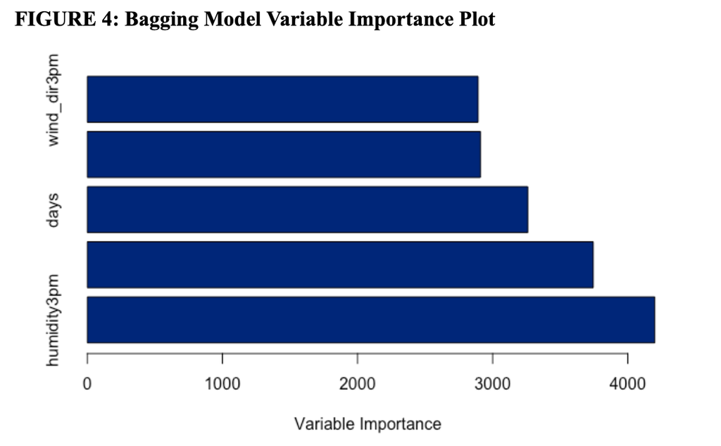

```r
knitr::include_graphics("Screen Shot 2021-12-14 at 11.01.06 PM.png")
```

# Conclusions / Future Work

Overall, our final boosted model had the highest level of prediction accuracy with a log loss error of 0.30458. We were pretty satisfied with this score, as our boosted model was much better than the naive model of 0.69, so we were successful in building a pretty accurate rainfall predictor model.

For future work, we would probably explore the variables found to be most significant like humidity, location and pressure more in depth. Taking a look at how one could use these variables in particular to build an accurate model would be the next step, because our results indicate that a few variables have the most pull in predicting rainfall. We believe one could build a pretty accurate model with far less variables than we utilized in our models, as our results point towards a select few variables being the important predictors in rainfall.

# Appendix

All code for this project is in the repository linked below. The final submissions for each project to kaggle are also within the github. There is one set of code for the AirBNB project, and the remaining two are for the Rainfall project.

https://github.com/Akhil-Ghosh/338_final